# 7_3_Homework_Solution

# References

1. Hyndman, R.J., & Athanasopoulos, G., 2021. *Forecasting: principles and practice*. 3rd edition.

# Packages

```r
library(fpp3)
```

# Homework

Consider the last five years of the Gas data from `aus_production`

```r
gas <- tail(aus_production, 5*4) %>% select(Gas)
gas
```

```
## # A tsibble: 20 x 2 [1Q]
##      Gas Quarter
##    <dbl>   <qtr>
##  1   221 2005 Q3
##  2   180 2005 Q4
##  3   171 2006 Q1
##  4   224 2006 Q2
##  5   233 2006 Q3
##  6   192 2006 Q4
##  7   187 2007 Q1
##  8   234 2007 Q2
##  9   245 2007 Q3
## 10   205 2007 Q4
## 11   194 2008 Q1
## 12   229 2008 Q2
## 13   249 2008 Q3
## 14   203 2008 Q4
## 15   196 2009 Q1
## 16   238 2009 Q2
## 17   252 2009 Q3
## 18   210 2009 Q4
## 19   205 2010 Q1
## 20   236 2010 Q2
```

## a. Use `classical_decomposition` with `type=multiplicative` to calculate the trend-cycle and seasonal indices

```r
# Let us compute the classical decomposition using the function in the feasts library:
classical_dec <- gas %>%
  model(
    classical_decomposition(Gas ~ season(4), type = "multiplicative")
  ) %>%
  components()

classical_dec
```

```
## # A dable: 20 x 7 [1Q]
## # Key:     .model [1]
## # :        Gas = trend * seasonal * random
##    .model                      Quarter   Gas trend seasonal random season_adjust
##    <chr>                         <qtr> <dbl> <dbl>    <dbl>  <dbl>         <dbl>
##  1 "classical_decomposition(G~ 2005 Q3   221   NA     1.13  NA              196.
##  2 "classical_decomposition(G~ 2005 Q4   180   NA     0.925 NA              195.
##  3 "classical_decomposition(G~ 2006 Q1   171  200.    0.875  0.974          195.
##  4 "classical_decomposition(G~ 2006 Q2   224  204.    1.07   1.02           209.
##  5 "classical_decomposition(G~ 2006 Q3   233  207     1.13   1.00           207.
##  6 "classical_decomposition(G~ 2006 Q4   192  210.    0.925  0.987          208.
##  7 "classical_decomposition(G~ 2007 Q1   187  213     0.875  1.00           214.
##  8 "classical_decomposition(G~ 2007 Q2   234  216.    1.07   1.01           218.
##  9 "classical_decomposition(G~ 2007 Q3   245  219.    1.13   0.996          218.
## 10 "classical_decomposition(G~ 2007 Q4   205  219.    0.925  1.01           222.
## 11 "classical_decomposition(G~ 2008 Q1   194  219.    0.875  1.01           222.
## 12 "classical_decomposition(G~ 2008 Q2   229  219     1.07   0.974          213.
## 13 "classical_decomposition(G~ 2008 Q3   249  219     1.13   1.01           221.
## 14 "classical_decomposition(G~ 2008 Q4   203  220.    0.925  0.996          219.
## 15 "classical_decomposition(G~ 2009 Q1   196  222.    0.875  1.01           224.
## 16 "classical_decomposition(G~ 2009 Q2   238  223.    1.07   0.993          222.
## 17 "classical_decomposition(G~ 2009 Q3   252  225.    1.13   0.994          224.
## 18 "classical_decomposition(G~ 2009 Q4   210  226     0.925  1.00           227.
## 19 "classical_decomposition(G~ 2010 Q1   205   NA     0.875 NA              234.
## 20 "classical_decomposition(G~ 2010 Q2   236   NA     1.07  NA              220.
```

## b. Compute and plot the seasonally adjusted data.

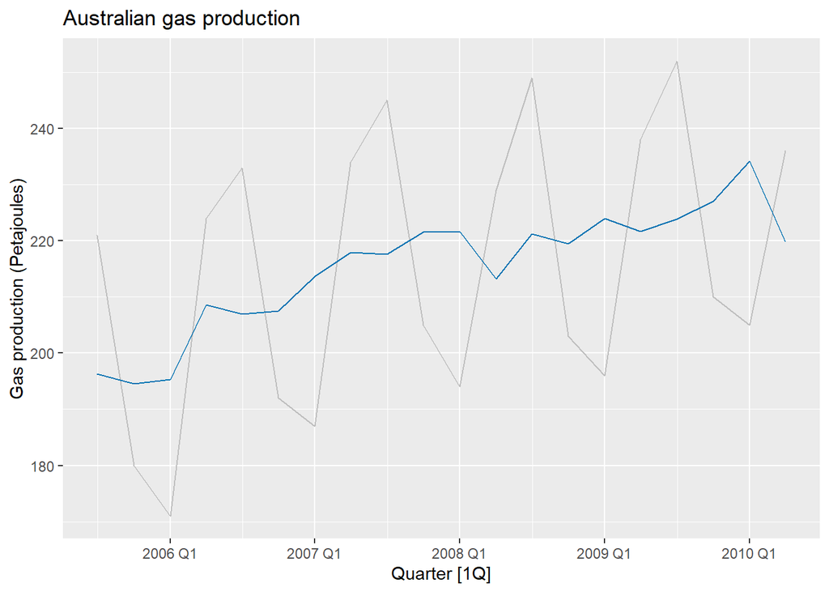

```r
classical_dec %>%
  as_tsibble() %>%
  autoplot(Gas, colour = "gray") +
  geom_line(aes(y=season_adjust), colour = "#0072B2") +
  labs(y = "Gas production (Petajoules)",
       title = "Australian gas production")
```

## c. Compute manually the classical decomposition of the series (as we did in class, but keep in mind that this scheme is multiplicative and that now the seasonal period is 4 instead of 12).

### 1. Compute the trend with a 2x4 MA

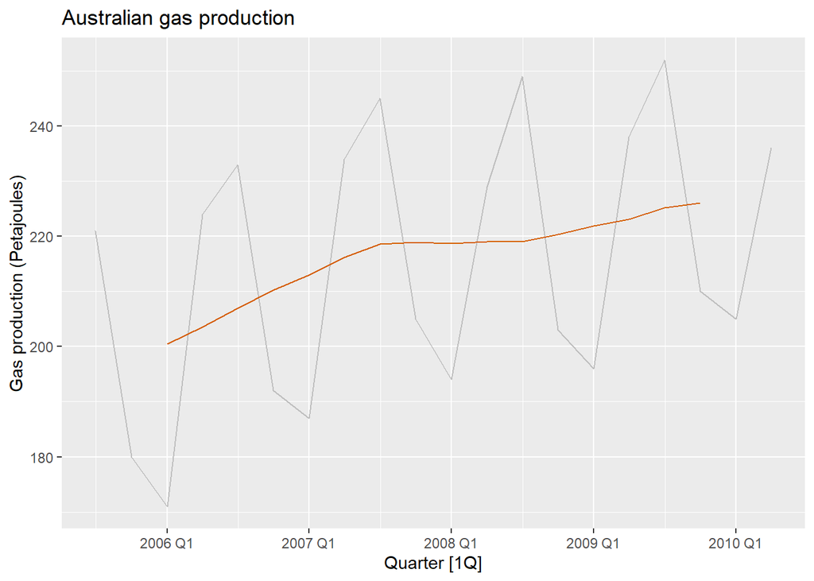

```r
# Compute moving averages
# Because the seasonal period is 12, we need a 2x12-MA
manual_decomposition <- gas %>%
  mutate(
    `4-MA` = slider::slide_dbl(Gas, mean,
                     .before = 1, .after = 2, .complete = TRUE),
    `2x4-MA` = slider::slide_dbl(`4-MA`, mean,
                      .before = 1, .after = 0, .complete = TRUE)
  )

# Plot the computed trend
manual_decomposition %>%
  autoplot(Gas, colour = "gray") +
  geom_line(aes(y = `2x4-MA`), colour = "#D55E00") +
  labs(y = "Gas production (Petajoules)",
       title = "Australian gas production")
```

### 2. Compute the de-trended component:

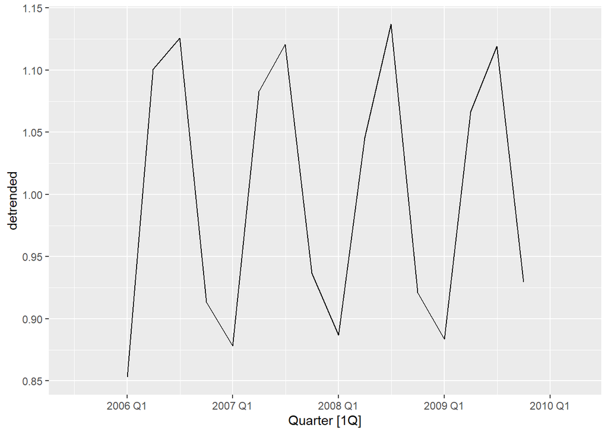

```r
# Compute the detrended component:
manual_decomposition <- manual_decomposition %>%
  mutate(detrended = Gas / `2x4-MA`,
         n_quarter = quarter(Quarter)) # Add an identifier for the month (used later for a join statement)

manual_decomposition %>% autoplot(detrended)
```

### 3. Compute the seasonal component grouping and averaging the detrended component

```r
res <- manual_decomposition %>%
  index_by(n_quarter) %>%

  #Compute seasonal component
  summarise(
    seasonal_c = mean(detrended, na.rm = TRUE)
  ) %>%

  ungroup()

res
```

```
## # A tsibble: 4 x 2 [1]
##   n_quarter seasonal_c
##       <int>      <dbl>
## 1         1      0.875
## 2         2      1.07
## 3         3      1.13
## 4         4      0.925
```

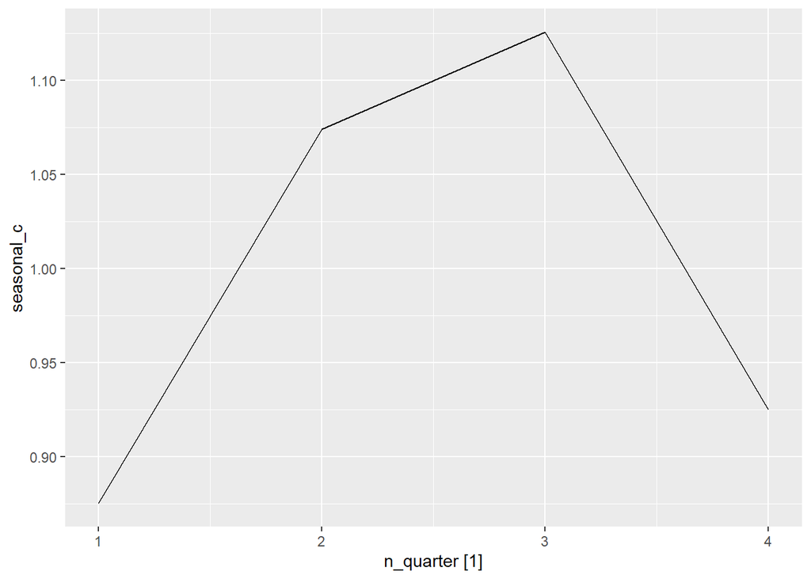

```r
#Check the aspect of the obtained seasonal component
res %>%
  autoplot(seasonal_c)
```

This is the resulting seasonal component of our decomposition:

- The first point is the value of the seasonal component for Q1
- The second point is the value of the seasonal component for Q2
- …

### 4. Correct the seasonal components so that they add to $m$

Check if the values of the seasonal component add up to m = 4

```r
#The sum does not add up to 4
sum(res$seasonal_c)
```

```
## [1] 3.999897
```

The sum is really close to 4. We are going to make the correction nonetheless to show how to do it:

- Compute sum_dev (difference between m and the actual sum of the seasonal component).
- This should be equal to 4. We distribute this difference evenly over the seasonal component

```r
m = 4
sum_dev = m - sum(res$seasonal_c)

res <- res %>%
  # Correction so that the sum of the seasoan components is 0
  mutate(seasonal_c = seasonal_c  + sum(sum_dev)/m)

sum(res$seasonal_c)
```

```
## [1] 4
```

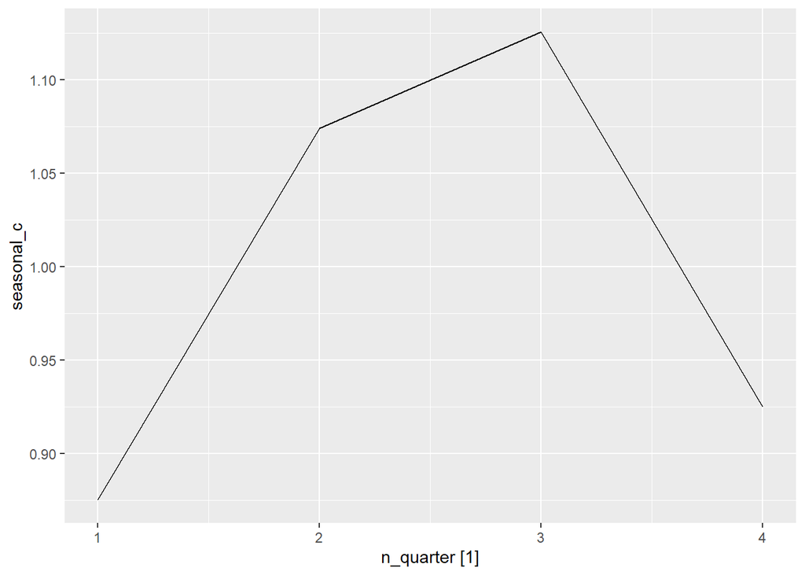

```r
#Check the aspect of the obtained seasonal component
res %>%
  autoplot(seasonal_c)
```

Now the seasonal component adds up to $m$ (4). We now bring the seasonal component back to the original dataset:

```r
# Bring seasonal component into the dataset (I chose to use a "join" statement, very convenient)
manual_decomposition <- left_join(manual_decomposition, res, by = "n_quarter")
manual_decomposition
```

```
## # A tsibble: 20 x 7 [1Q]
##      Gas Quarter `4-MA` `2x4-MA` detrended n_quarter seasonal_c
##    <dbl>   <qtr>  <dbl>    <dbl>     <dbl>     <int>      <dbl>
##  1   221 2005 Q3    NA       NA     NA             3      1.13
##  2   180 2005 Q4   199       NA     NA             4      0.925
##  3   171 2006 Q1   202      200.     0.853         1      0.875
##  4   224 2006 Q2   205      204.     1.10          2      1.07
##  5   233 2006 Q3   209      207      1.13          3      1.13
##  6   192 2006 Q4   212.     210.     0.913         4      0.925
##  7   187 2007 Q1   214.     213      0.878         1      0.875
##  8   234 2007 Q2   218.     216.     1.08          2      1.07
##  9   245 2007 Q3   220.     219.     1.12          3      1.13
## 10   205 2007 Q4   218.     219.     0.937         4      0.925
## 11   194 2008 Q1   219.     219.     0.887         1      0.875
## 12   229 2008 Q2   219.     219      1.05          2      1.07
## 13   249 2008 Q3   219.     219      1.14          3      1.13
## 14   203 2008 Q4   222.     220.     0.921         4      0.925
## 15   196 2009 Q1   222.     222.     0.883         1      0.875
## 16   238 2009 Q2   224      223.     1.07          2      1.07
## 17   252 2009 Q3   226.     225.     1.12          3      1.13
## 18   210 2009 Q4   226.     226      0.929         4      0.925
## 19   205 2010 Q1    NA       NA     NA             1      0.875
## 20   236 2010 Q2    NA       NA     NA             2      1.07
```

### 5. Obtain the remainder component

Now that we have the seasonal component, we obtain the remainder component by dividing detrended series by the seasonal component component:

```r
# Compute remainder component:
manual_decomposition <- manual_decomposition %>%
  mutate(remainder = detrended / seasonal_c)

select(manual_decomposition, Quarter, Gas, `2x4-MA`, seasonal_c, remainder)
```

```
## # A tsibble: 20 x 5 [1Q]
##    Quarter   Gas `2x4-MA` seasonal_c remainder
##      <qtr> <dbl>    <dbl>      <dbl>     <dbl>
##  1 2005 Q3   221      NA       1.13     NA
##  2 2005 Q4   180      NA       0.925    NA
##  3 2006 Q1   171     200.      0.875     0.974
##  4 2006 Q2   224     204.      1.07      1.02
##  5 2006 Q3   233     207       1.13      1.00
##  6 2006 Q4   192     210.      0.925     0.987
##  7 2007 Q1   187     213       0.875     1.00
##  8 2007 Q2   234     216.      1.07      1.01
##  9 2007 Q3   245     219.      1.13      0.996
## 10 2007 Q4   205     219.      0.925     1.01
## 11 2008 Q1   194     219.      0.875     1.01
## 12 2008 Q2   229     219       1.07      0.974
## 13 2008 Q3   249     219       1.13      1.01
## 14 2008 Q4   203     220.      0.925     0.996
## 15 2009 Q1   196     222.      0.875     1.01
## 16 2009 Q2   238     223.      1.07      0.993
## 17 2009 Q3   252     225.      1.13      0.994
## 18 2009 Q4   210     226       0.925     1.00
## 19 2010 Q1   205      NA       0.875    NA
## 20 2010 Q2   236      NA       1.07     NA
```

### 6. Check your absolute errors:

We have all the components. We are now going to compute the maximum absolute errors of our manual computation, comparing it with the results provided by the function `classical_decomposition()`

```r
# Evaluation of absolute errors
max_err_seasonal = max(classical_dec$seasonal - manual_decomposition$seasonal_c, na.rm = TRUE)
max_err_trend = max(classical_dec$trend - manual_decomposition$`2x4-MA`, na.rm = TRUE)
max_err_rand = max(classical_dec$random - manual_decomposition$remainder, na.rm = TRUE)

max(c(max_err_seasonal, max_err_trend, max_err_rand))
```

```
## [1] 3.720274e-06
```

The errors are small enough for us to consider that we have correctly implemented the algorithm in the function `classical_decomposition()`. It would be interesting to explore the specific reasons for this deviation, but that is something we will not do.

## d. Change one observation to be an outlier (e.g., add 300 to one observation), and recompute the seasonally adjusted data. What is the effect of the outlier?

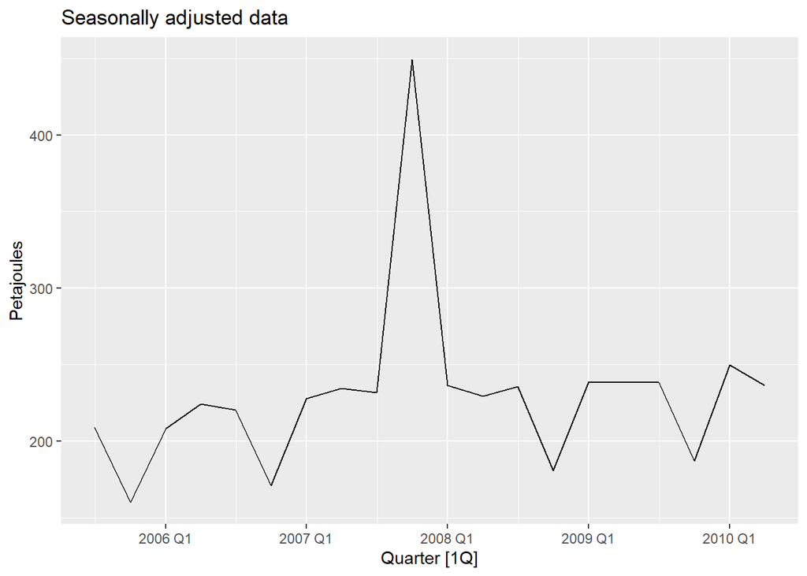

```r
gas %>%
  mutate(Gas = if_else(Quarter == yearquarter("2007Q4"), Gas + 300, Gas)) %>%
  model(decomp = classical_decomposition(Gas, type = "multiplicative")) %>%
  components() %>%
  as_tsibble() %>%
  autoplot(season_adjust) +
  labs(title = "Seasonally adjusted data", y = "Petajoules")
```

- The outlier is more or less in the middle of the series.
- The trend is approximated using a 2x4-MA. Since the outlier is in the middle of the series, this information is in the region where the moving average can be computed and the information of the outlier is captured by the trend component.
- The detrended component also inherits the information of the outlier, since it is computed as $y_t/T_t$.
- The seasonal component is computed averaging this detrended component and therefore is also affected by the outlier. It will not accurately approximate the seasonal component.

As a result the seasonally adjusted data still has seasonality, because we have not adequately captured the seasonal component.

## e. Does it make any difference if the outlier is near the end rather than in the middle of the series?

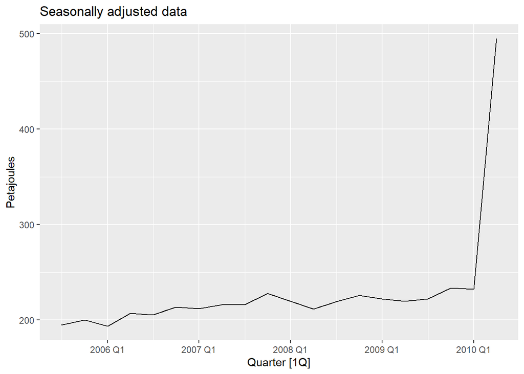

```r
gas %>%
  mutate(Gas = if_else(Quarter == yearquarter("2010Q2"), Gas + 300, Gas)) %>%
  model(decomp = classical_decomposition(Gas, type = "multiplicative")) %>%
  components() %>%
  as_tsibble() %>%
  autoplot(season_adjust) +
  labs(title = "Seasonally adjusted data", y = "Petajoules")
```

- The outlier is located at the last point of the series.
- The trend is approximated using a 2x4-MA. Since the outlier is at the very end of the series, this information is in the region where the 2x4 moving average cannot be computed and the information of the outlier is not captured by the trend component.
- The detrended component is defined in exactly the same region as the trend approximation, since it is computed as $y_t/T_t$. Therefore the detrended component does not capture the information about the outlier.
- The seasonal component is computed averaging this detrended component. Therefore it does not inherit information from the outlier. The seasonal component is not affected by the presence of this outlier.

The seasonally adjusted data does not exhibit seasonality because the seasonal component was correctly computed since it remained unaffected by the outlier. The outlier is however very present in the seasonally adjusted data.